# Comparing model fits if we add in 2017 data

Mathew Kiang

1/7/2019

## Introduction

The 2017 multiple cause of death data have just been released. In what is now a bit of a tradition, I will compare the projections from our paper (which had only up to 2015 data) to the observed data for 2016 and 2017. See the [2016 version of this analysis](https://htmlpreview.github.io/?https://github.com/mkiang/opioid_trends/blob/master/rmds/add_analyses/add_2016_data.html) here ([code](https://github.com/mkiang/opioid_trends/blob/master/rmds/add_analyses/add_2016_data.Rmd)).

We will compare two sets of joinpoint models:

1. Our published model that uses 1979 to 2015 (with 2017 projected out)
2. The same model but with 1979 to 2017 data

## Imports

Let’s load the packages we will need and `source()` one of my themes.

```r
library(tidyverse)
library(patchwork)    # devtools::install_github("thomasp85/patchwork")
source(paste0("https://raw.githubusercontent.com/mkiang/",
              "opioid_hotspots/master/code/mk_nytimes.R"))
```

## Define helper functions

We’re going to define two helper functions. The first, `return_download_url()` just takes as an argument one of the years of analysis (2015 or 2017), one of the types of joinpoint analyses performed (rates_long, rate_ratio, broad_type, icd10_type), and the type of joinpoint results file (data, aapc, apc, etc.).

The second helper function then just imports the data from the specific URL and does some minor cleaning such as removing odd characters and appending the results year.

```r
## Helper functions
return_download_url <- function(r_year, results_type, file_type = "data") {
    ## Constants
    base_url <-  "https://raw.githubusercontent.com/mkiang/opioid_trends"
    url_dict <- list("2015" = "master",
                     "2017" = "with-2017-data")
    dir_dict <- list(rates_long = "01_opioid_rates_long",
                     rate_ratio = "02_opioid_rate_ratio",
                     broad_type = "03_opioid_rates_by_type",
                     icd10_type = "04_opioid_rates_icd10type")

    sprintf("%s/%s/joinpoint_analysis/%s/%s.%s.txt",
            base_url, url_dict[[as.character(r_year)]],
            dir_dict[[results_type]], dir_dict[[results_type]],
            file_type)
}

import_url_results <- function(r_year, results_type, file_type = "data") {

    df <- readr::read_delim(return_download_url(r_year, results_type, file_type),
                            delim = ";",
                            escape_double =  FALSE,
                            trim_ws = TRUE) %>%
        mutate(results_year = r_year)

    names(df) <- tolower(names(df))
    names(df) <- gsub(" ", "", names(df))
    names(df) <- gsub(",", "_", names(df))

    return(df)
}
```

## Comparing Figure 1

Now let’s download and clean up both the 2015 and 2017 results.

```r
## Opioid mortality rates and joinpoint fits
opioid_mort <- bind_rows(
    import_url_results(2015, "rates_long", "data"),
    import_url_results(2017, "rates_long", "data")
    ) %>%
    filter(opioid_type == "opioid",
           race != "total") %>%
    ungroup() %>%
    mutate(race_cat = factor(race,
                             levels = c("total", "white", "black"),
                             labels = c("Total", "White", "Black"),
                             ordered = TRUE))
```

Then we take the 2015 results and project out two years to 2017.

```r
## Project out the 2015 results to 2017
opioid_mort <- bind_rows(
    opioid_mort %>%
        filter(results_year == 2015, year == 2015) %>%
        mutate(year = 2016,
               model = (1 + as.numeric(gsub("^", "", apc, fixed = TRUE))/100) *
                   model,
               std_rate = NA,
               standarderror = NA),
     opioid_mort %>%
        filter(results_year == 2015, year == 2015) %>%
        mutate(year = 2017,
               model = (1 + as.numeric(gsub("^", "", apc, fixed = TRUE))/100)^2 *
                   model,
               std_rate = NA,
               standarderror = NA),
    opioid_mort
    )
```

We make the top plot (Fig 1a).

```r
p1 <- ggplot() +
    geom_point(data = opioid_mort %>%
                   filter(results_year == 2017),
               aes(x = year, y = std_rate,
                   group = race_cat, color = race_cat),
               alpha = .5) +
    geom_errorbar(data = opioid_mort %>%
                   filter(results_year == 2017),
               aes(x = year, group = race_cat, color = race_cat,
                   ymin = std_rate - 1.96 * standarderror,
                   ymax = std_rate + 1.96 * standarderror),
               alpha = .5, width = .15) +
    geom_line(data = opioid_mort,
              aes(x = year, y = model,
                  group = interaction(race_cat, results_year),
                  color = race_cat, linetype = as.factor(results_year)),
              alpha = .9) +
    mk_nytimes() +
    scale_color_brewer(NULL, palette = "Set1") +
    scale_linetype_manual("Joinpoint Model Fit",
                          values = c("dashed", "solid")) +
    scale_x_continuous(NULL) +
    scale_y_continuous("Opioid-related mortality rate")
```

Same steps as above except for the rate ratio which will be the bottom plot (Fig 1b).

```r
## Rate ratio
rate_ratios <- bind_rows(
    import_url_results(2015, "rate_ratio", "data"),
    import_url_results(2017, "rate_ratio", "data")
    )

## Project the 2015 model out one year
rate_ratios <- bind_rows(
    rate_ratios,
    rate_ratios %>%
        filter(results_year == 2015, year == 2015) %>%
        mutate(year = 2016,
               model = (1 + as.numeric(gsub("^", "", apc, fixed = TRUE))/100) *
                   model,
               opioid_rr = NA,
               standarderror = NA),
      rate_ratios %>%
        filter(results_year == 2015, year == 2015) %>%
        mutate(year = 2017,
               model = (1 + as.numeric(gsub("^", "", apc, fixed = TRUE))/100)^2 *
                   model,
               opioid_rr = NA,
               standarderror = NA)
    )
```

```r
p2 <- ggplot() +
    geom_point(data = rate_ratios %>%
                   filter(results_year == 2017),
               aes(x = year, y = opioid_rr),
               alpha = .5) +
    geom_errorbar(data = rate_ratios %>%
                      filter(results_year == 2017),
                  aes(x = year,
                      ymin = opioid_rr - 1.96 * standarderror,
                      ymax = opioid_rr + 1.96 * standarderror),
                  alpha = .5, width = .15) +
    geom_line(data = rate_ratios,
              aes(x = year, y = model,
                  group = results_year,
                  linetype = as.factor(results_year)),
              alpha = 1) +
    mk_nytimes(legend.position = "none") +
    scale_color_brewer(NULL, palette = "Set1") +
    scale_linetype_manual("Joinpoint Model Fit",
                          values = c("dashed", "solid")) +
    scale_x_continuous(NULL) +
    scale_y_continuous("Rate Ratio", trans = "log",
                       breaks = c(.5, 1, 2))
```

Print the figure:

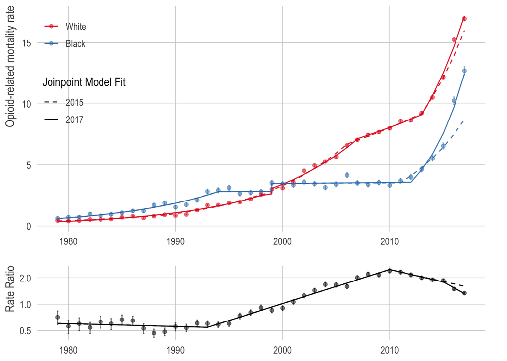

```r
fig1 <- p1 + p2 + plot_layout(ncol = 1, heights = c(3, 1))
print(fig1)
```

## Comparing Figure 3

We can do the steps as before, but for Figure 3. (Because the early parts of joinpoint regression are generally insensitive to changes at the end, I didn’t do this for Figure 2, but you could.)

```r
## By ICD10 type
icd10_types <- bind_rows(
    import_url_results(2015, "icd10_type", "data"),
    import_url_results(2017, "icd10_type", "data")
) %>%
    filter(race != "total",
           opioid_type %in%  c("heroin", "methadone", "natural",
                               "synth", "other_op")) %>%
    ungroup() %>%
    mutate(race_cat = factor(race,
                             levels = c("total", "white", "black"),
                             labels = c("Total", "White", "Black"),
                             ordered = TRUE),
           opioid_cat = factor(opioid_type,
                               levels = c("heroin", "methadone",
                                          "natural", "synth", "other_op"),
                               labels = c("Heroin", "Methadone",
                                          "Natural/Semi-natural",
                                          "Synthetic", "Unspecified"),
                               ordered = TRUE))
```

```r
## Project the 2015 model out one year
icd10_types <- bind_rows(
    icd10_types,
    icd10_types %>%
        filter(results_year == 2015, year == 2015) %>%
        mutate(year = 2016,
               model = (1 + as.numeric(gsub("^", "", apc, fixed = TRUE))/100) *
                   model,
               std_rate = NA,
               standarderror = NA),
      icd10_types %>%
        filter(results_year == 2015, year == 2015) %>%
        mutate(year = 2017,
               model = (1 + as.numeric(gsub("^", "", apc, fixed = TRUE))/100)^2 *
                   model,
               std_rate = NA,
               standarderror = NA)
    )

sub_types <- icd10_types %>%
    filter(!(opioid_type %in% c("methadone", "other_op")))
```

For ease of visualization, I’m going to remove methadone and other/unspecific opioids because the model fits are almost the same.

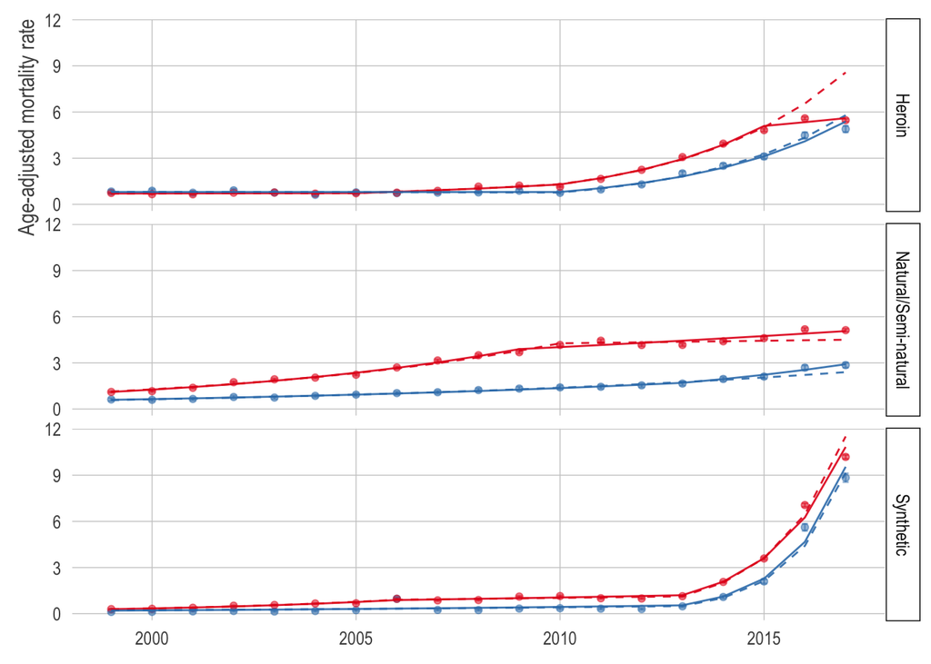

```r
fig3 <- ggplot() +
    geom_point(data = sub_types %>%
                   filter(results_year == 2017),
               aes(x = year, y = std_rate,
                   group = race_cat, color = race_cat),
               alpha = .5) +
    geom_errorbar(data = sub_types %>%
                      filter(results_year == 2017),
                  aes(x = year, group = race_cat, color = race_cat,
                      ymin = std_rate - 1.96 * standarderror,
                      ymax = std_rate + 1.96 * standarderror),
                  alpha = .5, width = .15) +
    geom_line(data = sub_types,
              aes(x = year, y = model,
                  group = interaction(race_cat, results_year),
                  color = race_cat, linetype = as.factor(results_year)),
              alpha = .9) +
    mk_nytimes(legend.position = "none") +
    facet_grid(opioid_cat ~ .) +
    scale_color_brewer(NULL, palette = "Set1") +
    scale_linetype_manual("Joinpoint Model Fit",
                          values = c("dashed", "solid")) +
    scale_x_continuous(NULL) +
    scale_y_continuous("Age-adjusted mortality rate")

print(fig3)
```

## Save the grobs

```r
saveRDS(fig1, "./../../output/add_analyses/fig1_with_2017.RDS")
saveRDS(fig3, "./../../output/add_analyses/fig3_with_2017.RDS")
```